# Custom `gglaplot`s

`gglaplot` contains several functions that take standard ggplot objects/layers and customises them to fit better with our style guide for data vis. Some of these just change some default settings to change the look of a chart, and others create new chart types.

They can be used similarly to ggplot objects, either inheriting aesthetics from an earlier call to `ggplot()` or having their own aesthetics defined.

As with `ggplot()` these functions work best with, and are designed for, **tidy** data.

These are the packages we’ll need:

```r
# For data manipulation
library(dplyr)
# For plotting
library(ggplot2)
library(gglaplot)
library(grid)
library(gridExtra)
# For working with dates
library(lubridate)
# For improving the labelling of our axis
library(scales)
# For spatial data
library(sf)
# For markdown table output
library(knitr)
```

And we can set the GLA theme at the start:

```r
theme_set(theme_gla())
```

All the data used in this vignette is included in the `gglaplot` package.

## Line charts

We’ll use the dataset comparing gender pay gaps between London and the rest of the UK

```r
LDNUK %>%
  head() %>%
  kable()
```

| Year | location | GPG |
| --- | --- | --- |
| 1997-01-01 | London | 22.39777 |
| 1998-01-01 | London | 22.04301 |
| 1999-01-01 | London | 21.87500 |
| 2000-01-01 | London | 23.87203 |
| 2001-01-01 | London | 23.35938 |
| 2002-01-01 | London | 23.26622 |

### Using `ggla_line()`

`ggla_line()` is the same as `ggplot2::geom_line()` except that it uses a round `lineend` style as default.

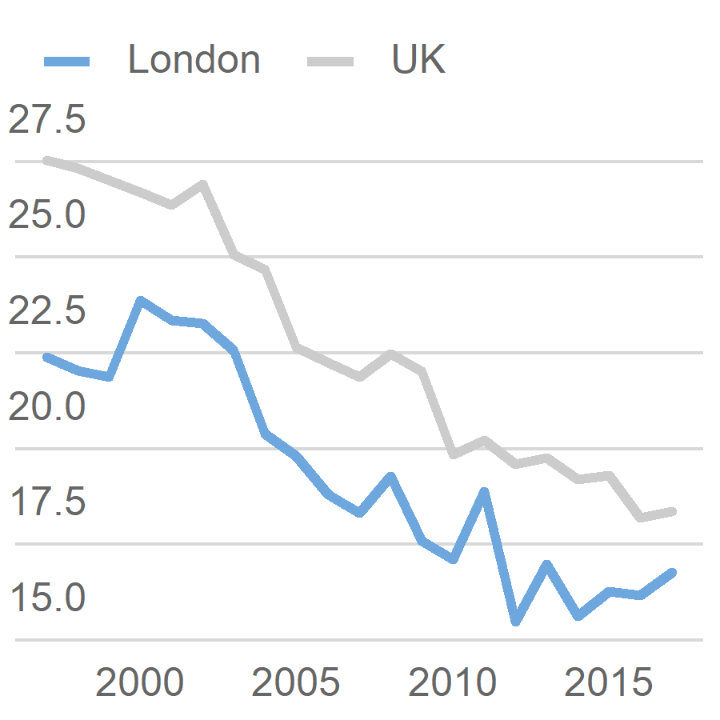

```r
pal <- gla_pal(gla_theme = "default", palette_type = "highlight", n = c(1, 1))

plot <- ggplot(data = LDNUK, mapping = aes(x = Year, y = GPG,
                                           group = location)) +
  scale_colour_manual(values = pal) +
  ggla_line(mapping = aes(colour = location))

plot
```

### Adding emphasis with `ggla_highlight()`

To highlight particular features of your data you can add emphasis with `ggla_highlight()`. This comes in 4 simple flavours, “start” and “end”, for highlighting your first or final data point, “min” and “max” for highlighting your minimum or maximum data points.

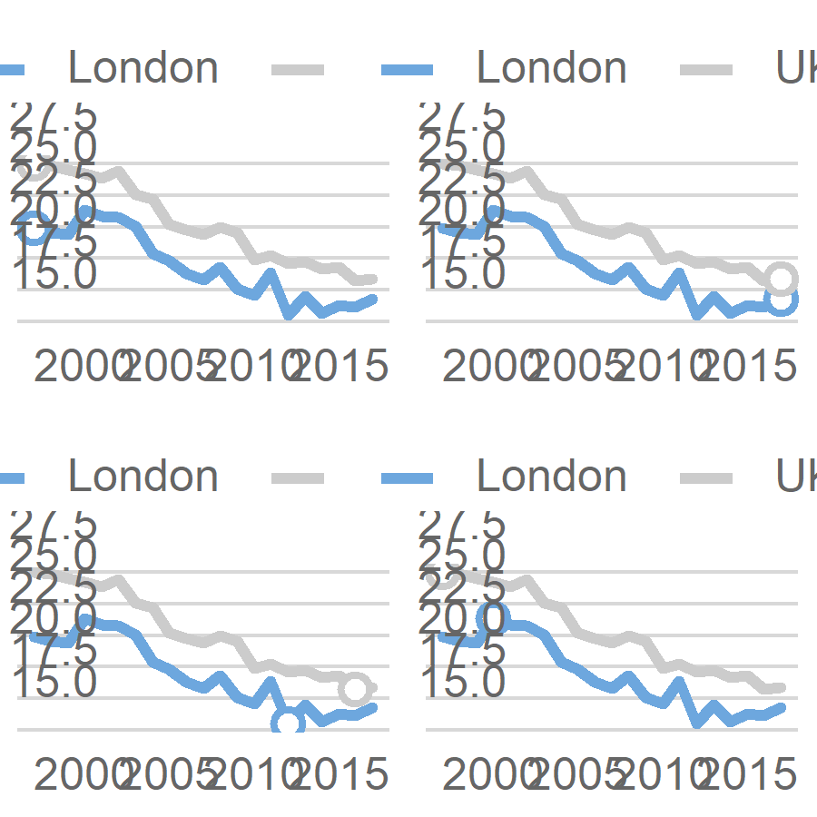

```r
p_start <- plot + ggla_highlight(aes(colour = location), filter_type = "start")
p_end <- plot + ggla_highlight(aes(colour = location), filter_type = "end")
p_min <- plot + ggla_highlight(aes(colour = location), filter_type = "min")
p_max <- plot + ggla_highlight(aes(colour = location), filter_type = "max")
grid.arrange(p_start, p_end, p_min, p_max, ncol = 2, nrow = 2)
```

`ggla_highlight()` also includes a more involved `xy` option for the `filter_type` argument for cases when you want to pick out a particular value which isn’t covered by start/end etc. This needs to be used along with at least one of the x_filt and y_filt arguments.

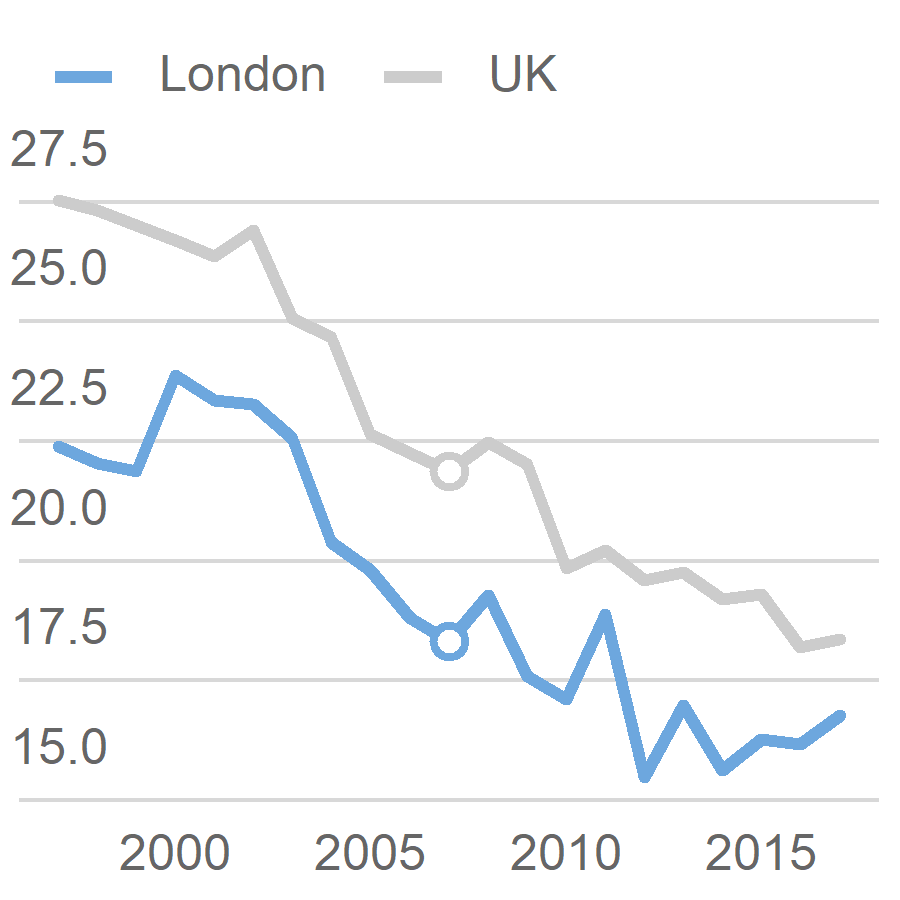

```r
plot +
  ggla_highlight(aes(colour = location), filter_type = "xy", x_filt = ymd("2007-01-01"))
```

You can also change the `geom` of `ggla_highlight()` to add labels. This will probably require a bit of fiddling around with the `position_nudge()` function to get them in the right place. If we’re labelling our data we might as well remove the legend.

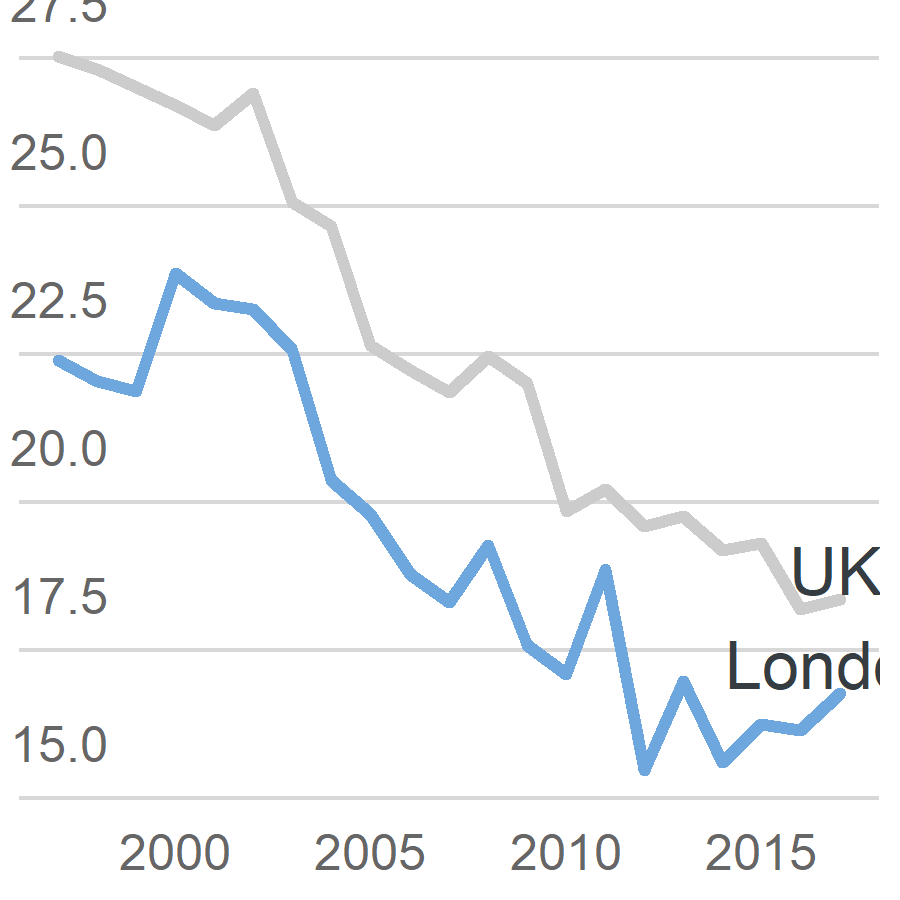

```r
plot +
  theme_gla(legend = FALSE) +
  ggla_highlight(mapping = aes(label = location),
                 filter_type = "end", geom = GeomTextHighlight,
                 position = position_nudge(x = -35, y = 0.5))
```

## Highlighting an area with `ggla_highlightarea()`

Areas of the graph can be highlighted with `ggla_highlightarea()`

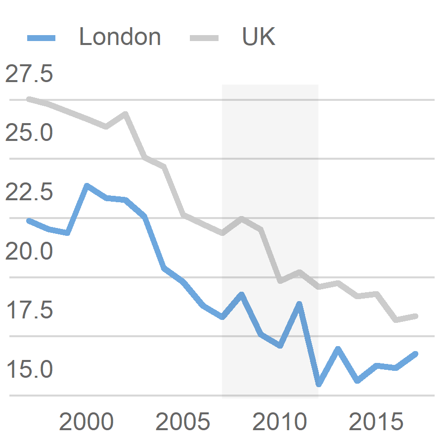

```r
plot +
  ggla_highlightarea(xmin = ymd("2007-01-01"), xmax = ymd("2012-01-01"))
```

## Adding lines

Different points in the data can also be highlighted by adding lines

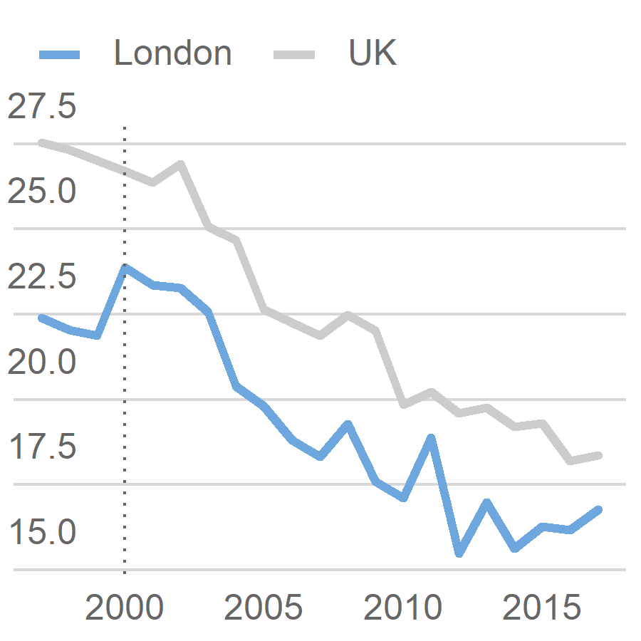

```r
plot +
  ggla_labelline(x1 = ymd("2000-01-01"))
```

## Extending the y-axis to 0.

If 0 is a meaningful number and the size of the plot allows it, it’s a good idea to include y=0 in your plot. `ggla_axisat0` will do this for you, as well as making it stronger than other grid lines.

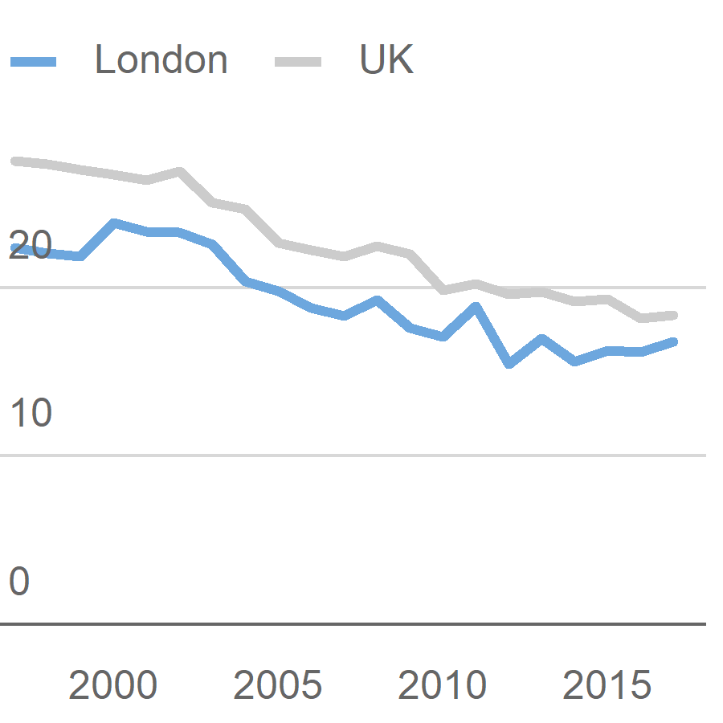

```r
plot +
  ggla_axisat0()
```

## Putting it all together with a few other formatting tweeks

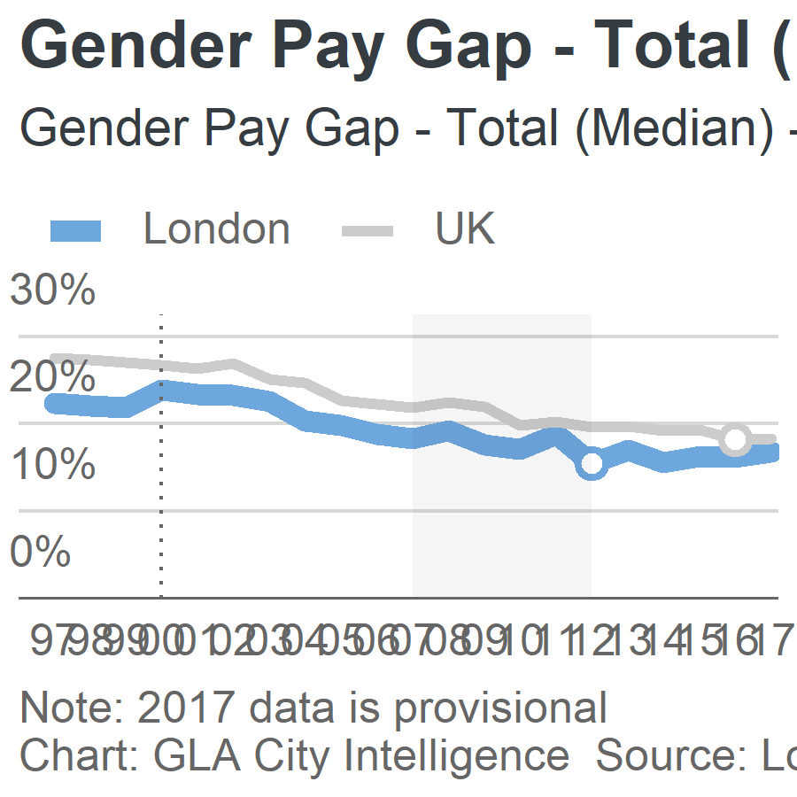

```r
ggplot(data = LDNUK, mapping = aes(x = Year, y = GPG, group = location,
                                   colour = location)) +
  # Add the ggla_line layer with an added aesthetic controlling
  # the thickness of the lines
  ggla_line(aes(size = location)) +
  # Control the scaling of the thickness, want London (location = 1)
  # to be thicker than UK (location = 2)
  scale_size_discrete(range = c(6 * mm_to_pt, 3 * mm_to_pt)) +
  # Add the palette
  scale_colour_manual(values = pal) +
  # Add some emphasis to the min values
  ggla_highlight(filter_type = "min") +
  # Add a context/highlight box between 2007 - 2012
  ggla_highlightarea(xmin = ymd("2007-01-01"), xmax = ymd("2012-01-01")) +
  # Add a line at 2000
  ggla_labelline(x1 = ymd("2000-01-01")) +
  # Extend the y axis to 0
  ggla_axisat0() +
  # Format the y-axis
  scale_y_continuous(expand = c(0, 0), limits = c(0, 32.5),
                      labels = dollar_format(prefix = "", suffix = "%")) +
  # Format the x-axis
  scale_x_date(date_breaks = "1 year", date_labels = "%y",
               expand = expand_scale(mult = c(0.05, 0.01))) +
  # Add titles and captions
  labs(
    title = "Gender Pay Gap - Total (Median)",
    subtitle = "Gender Pay Gap - Total (Median) - London VS UK",
    caption = "Note: 2017 data is provisional\nChart: GLA City Intelligence  Source: London Datastore"
    )
Warning: Using size for a discrete variable is not advised.
```

## Bar charts

We’ll use some data comparing Early Years Foundation Stage tests (EYFSP) by ethnicity for London and England

```r
EYFSP %>%
  kable()
```

| Ethnicity | Region | eyfsp |
| --- | --- | --- |
| White | London | 73 |
| Mixed | London | 75 |
| Asian | London | 73 |
| Black | London | 70 |
| Chinese | London | 79 |
| All pupils | London | 72 |
| White | England | 70 |
| Mixed | England | 71 |
| Asian | England | 67 |
| Black | England | 68 |
| Chinese | England | 72 |
| All pupils | England | 69 |

`ggla_horizbar()` makes horizontal bar charts, and can be used stacked or unstacked.

Here’s an unstacked, faceted example:

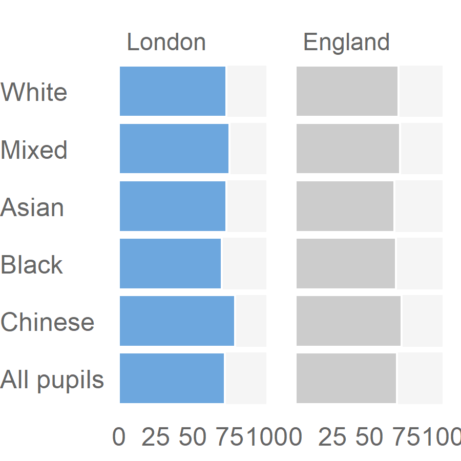

```r
barplot <- ggplot(EYFSP, aes(x = Ethnicity, y = eyfsp, fill = Region)) +
  # Add theme with gridlines and legend turned off
  theme_gla(xgridlines = FALSE, legend = FALSE) +
  # Add horizontal bar chart
  # to100 adds a context bar behind the data up to 100%
  ggla_horizbar(to100 = TRUE) +
  # Facet the data by region
  facet_grid(. ~ Region) +
  # Add our palette
  scale_fill_manual(values = pal)

barplot
```

We can add some additional formatting and labels to this

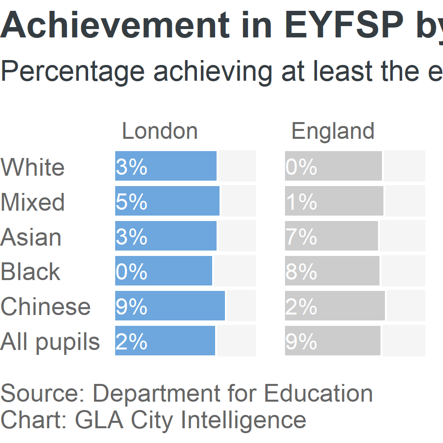

```r
(barplot +
   # Add formated labels to each bar
  geom_text(aes(label = paste(format(eyfsp, nsmall = 0), "%", sep = "")),
            y = 8, position = position_nudge(x = 0, y = 0), vjust = 0.50,
            colour = gla_default$background) +
   # Remove any labels from the x axis (effectively our y axis)
  theme(axis.text.x = element_blank()) +
   # Add titles
    labs(
      title = "Achievement in EYFSP by Ethnicity",
      subtitle = "Percentage achieving at least the expected standard in all ELGs (2017)",
      caption = "Source: Department for Education\nChart: GLA City Intelligence"
      )) %>%
  # Make labels left aligned
  left_align_labs()
```

By default, `ggplot2` aligns the plot labels (titles, captions etc) to the panel of the plot itself, not the whole plot area. As the ethnicity labels extend out to the left hand side of the plot, this ends up making the plot look a bit misaligned. `left_align_labs()` will adjust the alignment to be with respect to the whole plot area. This needs to be applied to the whole `ggplot` object, not just + on the end.

And a stacked example:

```r
AvAtt %>%
  kable()
```

| Region | Subject | Score |
| --- | --- | --- |
| London | English | 10.6 |
| England | English | 9.9 |
| London | Mathematics | 9.5 |
| England | Mathematics | 9.0 |
| London | English Baccalaureate | 13.6 |
| England | English Baccalaureate | 12.6 |
| London | Open | 15.1 |
| England | Open | 14.9 |

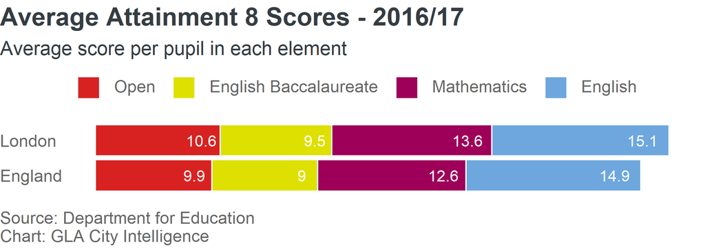

```r
numcats <- AvAtt %>%
  select(Subject) %>%
  unique() %>%
  nrow()

pal <- gla_pal(gla_theme = "default", palette_type = "categorical", n = numcats)

(ggplot(AvAtt,
        aes(x = Region, y = Score, fill = rev(Subject),
            label = round(Score, 1))) +
  theme_gla() +
  ggla_horizbar() +
  geom_text(position = position_stack(vjust = 0.85),
            color = gla_default$background) +
  theme(axis.text.x = element_blank()) +
  scale_fill_manual(values = pal,
                    breaks = rev(levels(AvAtt$Subject))) +
      labs(
        title = "Average Attainment 8 Scores - 2016/17",
        subtitle = "Average score per pupil in each element",
        caption = "Source: Department for Education\nChart: GLA City Intelligence"
        )) %>%
  left_align_labs()
```

## Donut charts

We’ll use some data on internet useage in London to illustrate donut charts

```r
Internet %>%
  kable()
```

| locat | usage | numUsers |
| --- | --- | --- |
| London | Used in last 3 months | 6591 |
| London | Not used in last 3 months | 496 |

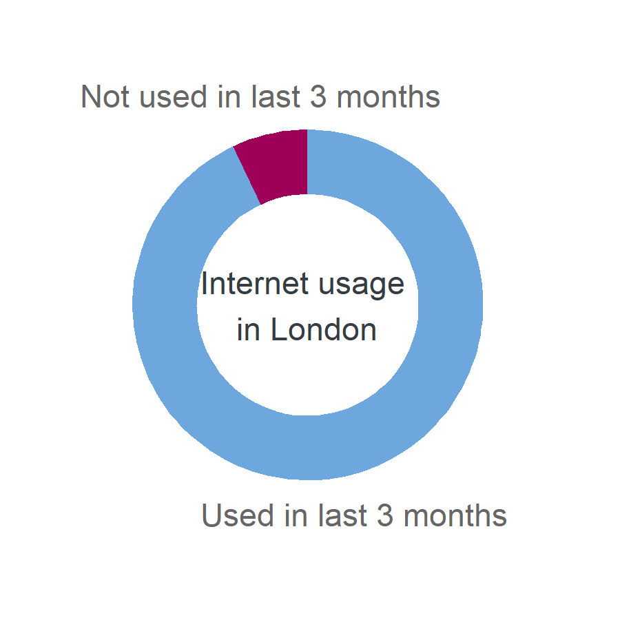

```r
numcats <- nrow(Internet)

pal <- gla_pal(gla_theme = "default", palette_type = "categorical", n = numcats)

ggplot(data = Internet, mapping = aes(fill = usage)) +
  ggla_donut(mapping = aes(label = usage, y = numUsers), stat = "identity",
             title = "Internet usage \nin London", base_size = 10) +
  scale_fill_manual(values = pal)
```

## Maps

We’ll use the results of the 2016 EU referendum in London to illustrate putting data on a map.

```r
EURef %>%
  select(-geometry) %>%
  head() %>%
  kable()
```

| Area_Code | Area | Leave | Remain | PropLeave | CatLeave |
| --- | --- | --- | --- | --- | --- |
| E09000001 | City of London | 1087 | 3312 | 24.71016 | 20% - 30% |
| E09000002 | Barking and Dagenham | 46130 | 27750 | 62.43909 | 60% - 70% |
| E09000003 | Barnet | 60823 | 100210 | 37.77052 | 30% - 40% |
| E09000004 | Bexley | 80886 | 47603 | 62.95169 | 60% - 70% |
| E09000005 | Brent | 48881 | 72523 | 40.26309 | 40% - 50% |
| E09000006 | Bromley | 90034 | 92398 | 49.35209 | 40% - 50% |

The leave vote has been seperated out into categories for each Borough. The geometry of each Borough is available on the [DataStore](https://data.london.gov.uk/dataset/statistical-gis-boundary-files-london).

To plot geographical data, you can use the `ggla_sf()` which is similar to the `ggplot::geom_sf()` function with different defaults to fit with our style guide. This function works with *simple features data*, as used in the [sf package](https://www.rdocumentation.org/packages/sf/versions/0.7-2). The geometry here is polygons, but `ggla_sf()` works with other geometry types.

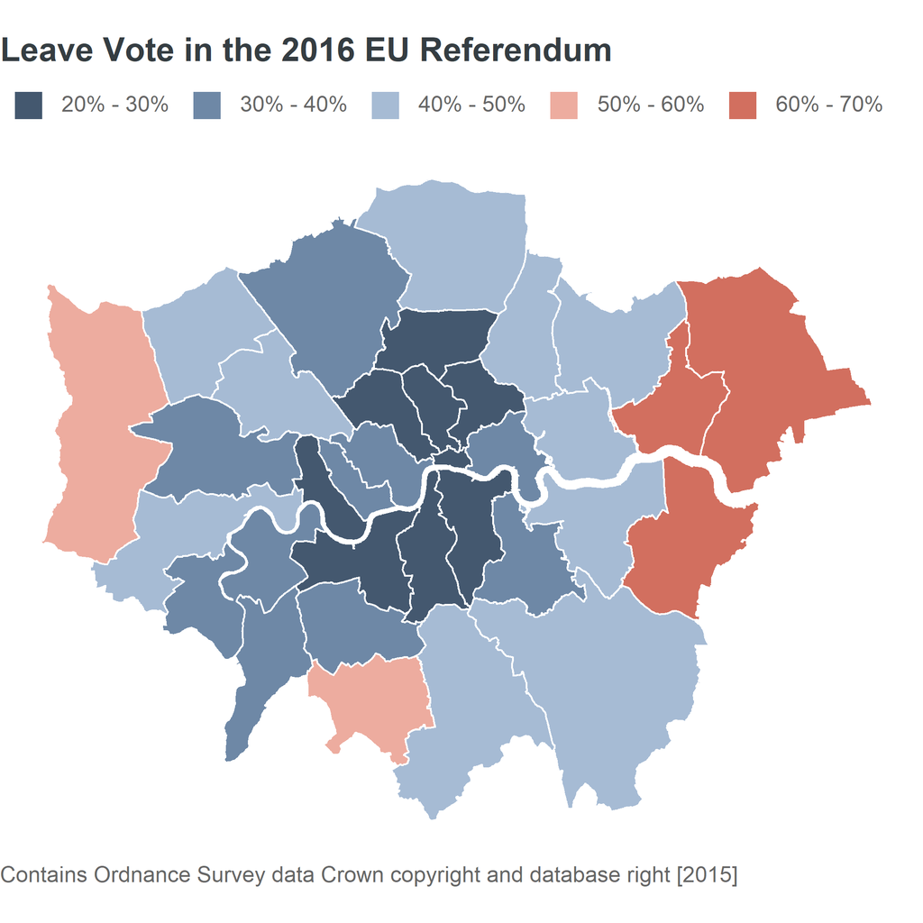

```r
# Generate a diverging palette - the edges get a bit dark so the remove margins
pal <- gla_pal(gla_theme = "default", palette_type = "diverging",
               main_colours = c("blue", "red"), n = 6, remove_margin = "both")

ggplot(EURef, aes(geometry = geometry, fill = CatLeave)) +
  ggla_sf() +
  scale_fill_manual(values = pal) +
  labs(
    title = "Leave Vote in the 2016 EU Referendum",
    caption = "Contains Ordnance Survey data Crown copyright and database right [2015]"
    )
```